# Data Science Specialization Capstone Project Milestone Report

Maurício Collaça

April 24, 2018

# 1 Introduction

The goal of this milestone report is to display what have been gotten by working with the sample data from the blogs, news and twitter texts provided by Swiftkey and demonstrate the project is on track to create the prediction algorithm.

The motivation for this report is to:

1. Demonstrate that the data have been successfully downloaded and loaded into a corpus.
2. Create summary statistics about the data sets.
3. Report any interesting findings.
4. Get feedback on the plans for creating a prediction algorithm and a Shiny application.

# 2 Resources used

Computer: Toshiba Satellite E55-A laptop

- Operating System: Microsoft Windows 8.1 64-bit
- Processor: Intel(R) Core(TM) i5-4200U CPU @2.30GHz
- Cores: 2
- Logical processors: 4
- Installed memory (RAM): 16GB

R libraries:

```r
packages <- c("parallel", "quanteda", "gridExtra", "ggplot2", "data.table")
noquote(c(R=paste(R.Version()[6:7], collapse="."), sapply(packages, function(x) {library(x, character.only=T, logical.return=T); as.character(packageVersion(x))})))
```

```
         R   parallel   quanteda  gridExtra    ggplot2 data.table
     3.4.4      3.4.4      1.2.0        2.3      2.2.1     1.11.2
```

# 3 Getting Data

Downloaded file:

```r
fileURL <- "https://d396qusza40orc.cloudfront.net/dsscapstone/dataset/Coursera-SwiftKey.zip"
dataDir <- "~/dsscapstone"
zipFile <- "Coursera-SwiftKey.zip"
zipfilePath <- file.path(dataDir, zipFile)
if(!file.exists(zipfilePath)) download.file(fileURL, destfile=zipfilePath, cacheOK = FALSE)
file.info(zipfilePath)[c(1,5)]
```

```
                                         size               ctime
~/dsscapstone/Coursera-SwiftKey.zip 574661177 2018-03-20 18:13:52
```

Compressed contents:

```r
(zipContents <- unzip(zipfilePath, list=TRUE))
```

```
                            Name    Length                Date
1                         final/         0 2014-07-22 10:10:00
2                   final/de_DE/         0 2014-07-22 10:10:00
3  final/de_DE/de_DE.twitter.txt  75578341 2014-07-22 10:11:00
4    final/de_DE/de_DE.blogs.txt  85459666 2014-07-22 10:11:00
5     final/de_DE/de_DE.news.txt  95591959 2014-07-22 10:11:00
6                   final/ru_RU/         0 2014-07-22 10:10:00
7    final/ru_RU/ru_RU.blogs.txt 116855835 2014-07-22 10:12:00
8     final/ru_RU/ru_RU.news.txt 118996424 2014-07-22 10:12:00
9  final/ru_RU/ru_RU.twitter.txt 105182346 2014-07-22 10:12:00
10                  final/en_US/         0 2014-07-22 10:10:00
11 final/en_US/en_US.twitter.txt 167105338 2014-07-22 10:12:00
12    final/en_US/en_US.news.txt 205811889 2014-07-22 10:13:00
13   final/en_US/en_US.blogs.txt 210160014 2014-07-22 10:13:00
14                  final/fi_FI/         0 2014-07-22 10:10:00
15    final/fi_FI/fi_FI.news.txt  94234350 2014-07-22 10:11:00
16   final/fi_FI/fi_FI.blogs.txt 108503595 2014-07-22 10:12:00
17 final/fi_FI/fi_FI.twitter.txt  25331142 2014-07-22 10:10:00
```

Languages found:

```r
langFilePattern <- "^final/(.._..)/.._...+\\.txt$"
unique(sub(langFilePattern, "\\1", grep(langFilePattern, zipContents$Name, value = TRUE)))
```

```
[1] "de_DE" "ru_RU" "en_US" "fi_FI"
```

The scope of this project is the English language. After uncompressing the English files and prior to build a corpus it is necessary to fix unexpected end of file caused by the `\032` character, only when running on Windows platforms, which is the case.

```r
unzipFiles <- sort(grep("^final/en_US/.._...+\\.txt$", zipContents$Name, value=T))
files <- file.path(dataDir, basename(unzipFiles))
docs <- sub(file.path(dataDir, "en_US\\.(.*)\\.txt$"), "\\1", files)
if(!all(file.exists(files))) unzip(zipfilePath, files=unzipFiles, setTimes=T, exdir=dataDir, junkpath=T)
fix.files <- function(f, basenamer = function(x) basename(x)) {
    # binary open avoids unexpected end of file on readLines() on Windows platforms
    con <- file(f, open = "rb")
    # removing unexpected end of file character "\032" on Windows platforms
    buffer <- gsub("\032", "", readLines(con, skipNul=TRUE))
    close(con)
    outFile <- file.path(dirname(f), basenamer(f))
    con <- file(outFile, "wb")
    writeLines(buffer, con)
    close(con)
    outFile
}
if(!file.exists(paste0(dataDir, "/fixed"))) {
    cluster <- makeCluster(detectCores())
    out <- parSapply(cluster, files, fix.files) #35s
    stopCluster(cluster)
    writeLines("", paste0(dataDir, "/fixed"))
}
```

Summarize files via [GNU coreutils wc](http://www.gnu.org/software/coreutils/wc):

```r
wc <- function(paths) {
    require(parallel)
    cluster <- makeCluster(detectCores())
    ret <- parSapplyLB(cluster, paths, function(x)
        as.integer(unlist(strsplit(system(paste("wc -l -w -c -L", x), TRUE),"\\s+"))[2:5]))
    stopCluster(cluster)
    rownames(ret) <- c("lines", "words", "bytes", "longest.line")
    data.frame(t(ret))
}
(wordcounts <- wc(files))
```

```
                                  lines    words     bytes longest.line
~/dsscapstone/en_US.blogs.txt    899288 37272578 209260726        40832
~/dsscapstone/en_US.news.txt    1010242 34309642 204801643        11384
~/dsscapstone/en_US.twitter.txt 2360148 30341028 164745183          140
```

```r
c(colSums(wordcounts[1:3]), longest.line=max(wordcounts[4]))
```

```
       lines        words        bytes longest.line
     4269678    101923248    578807552        40832
```

# 4 Exploratory Data Analysis

As defined in [Wikipedia](https://en.wikipedia.org/wiki/N-gram), an n-gram is a contiguous sequence of n items from a given sample of text or speech.

It’s assumed that the optimal unit of a sample text to create n-grams is the text sentence, otherwise n-grams could be created crossing sentences, e.g., a bigram composed by the last word of a given sentence and the first word of the very next sentence.

## 4.1 Creating the corpus

Creates one corpus per file, each corpus document containing a single line.

```r
for(i in seq_along(files)) {
    corpus <- paste0(docs[i], ".corpus1")
    corpusFile <- file.path(dataDir, paste0(corpus, ".rda"))
    if(!file.exists(corpusFile)) { #62s
        buffer <- readLines(files[i], skipNul=TRUE, encoding = "UTF-8")
        tmp <- corpus(buffer)
        docnames(tmp) <- NULL
        assign(corpus, tmp)
        rm(buffer, tmp)
        save(list=corpus, file=corpusFile, compress = FALSE)
    } else load(corpusFile) #43s
}
```

Summary

```r
summary.corpora <- function(corpus.names) {
    bind_rows(lapply(corpus.names, function(corpus.name) {
        corpus <- get(corpus.name)
        data.frame(Corpus = corpus.name,
                   Documents = ndoc(corpus),
                   Sentences = sum(nsentence(corpus)),
                   Tokens = sum(ntoken(corpus, remove_punct=TRUE)),
                   Megabytes = round(as.numeric(object.size(corpus))/1024/1024),
                   stringsAsFactors = FALSE)
    }))
}
summariesFile <- file.path(dataDir, "corpora1.summary.rda")
if(!file.exists(summariesFile)) {
    corpora1.summary <- summary.corpora(paste0(docs,".corpus1")) #42min
    save(corpora1.summary, file=summariesFile, compress=FALSE)
} else load(summariesFile)
corpora1.summary
```

```
           Corpus Documents Sentences   Tokens Megabytes
1   blogs.corpus1    899288   2367316 37296232       247
2    news.corpus1   1010242   1993117 34258969       249
3 twitter.corpus1   2360148   3770706 29959374       301
```

```r
colSums(corpora1.summary[,-1])
```

```
Documents Sentences    Tokens Megabytes
  4269678   8131139 101514575       797
```

```r
# for(i in seq_along(files)) {
#     corpus1 <- paste0(docs[i], ".corpus1")
#     corpus2 <- paste0(docs[i], ".corpus2")
#     corpusFile <- file.path(dataDir, paste0(corpus2, ".rda"))
#     if(!file.exists(corpusFile)) { #33min
#         tmp <- corpus_reshape(get(corpus1), to="sentences", use_docvars=FALSE)
#         docnames(tmp) <- NULL
#         assign(corpus2, tmp)
#         rm(tmp)
#         save(list=corpus2, file=corpusFile, compress = FALSE)
#     } else load(corpusFile) #43s
#     rm(list=corpus1)
# }
```

```r
# summariesFile <- file.path(dataDir, "corpora2.summary.rda")
# if(!file.exists(summariesFile)) {
#     corpora2.summary <- summary.corpora(paste0(docs,".corpus2")) #74min
#     save(corpora2.summary, file=summariesFile, compress=FALSE)
# } else load(summariesFile)
# corpora2.summary
# colSums(corpora2.summary[,-1])
```

## 4.2 Generating word tokens

Generating word tokens (unigrams) with the following transformations:

```r
for (doc in docs) { # 46min
    #vvvvv
    # corpus <- paste0(doc, ".corpus2")
    corpus <- paste0(doc, ".corpus1")
    #^^^^^
    corpusFile <- file.path(dataDir, paste0(corpus, ".rda"))
    tokens <- paste0(doc, ".tokens")
    tokensFile <- file.path(dataDir, paste0(tokens, ".rda"))
    if(!file.exists(tokensFile)) {
        #vvvvv
        # assign(tokens, tokens(get(corpus), remove_numbers=T, remove_punct=T, remove_symbols=T,
        #                       remove_separators=T, remove_twitter=T, remove_hyphens=T, remove_url=T))
        assign(tokens, tokens(get(corpus), what="sentence"))
        assign(tokens, paste("#s#", get(tokens), "#e#"))
        assign(tokens, tokens(get(tokens),
                              remove_numbers=T,
                              remove_punct=T,
                              remove_symbols=T,
                              remove_separators=T,
                              remove_twitter=FALSE,
                              remove_hyphens=T,
                              remove_url=T))
        #^^^^^
        assign(tokens, tokens_remove(get(tokens), max_nchar = 20L))
        assign(tokens, tokens_tolower(get(tokens), keep_acronyms = FALSE))
        #vvvvv unknown words
        freq1 <- as.data.table(textstat_frequency(dfm(get(tokens), tolower=FALSE, ngrams=1, concatenator=" "))[, 1:2])[frequency==1]
        assign(tokens, tokens_replace(get(tokens), freq1$feature, replacement = rep("#u#", nrow(freq1)))) #reduces types in around 50%
        rm(freq1)
        #^^^^^
        save(list=tokens, file=tokensFile, compress = FALSE)
        #rm(list=tokens)
    }
    rm(list=corpus)
}
```

Summary

```r
summariesFile <- file.path(dataDir, "tokens.summary.rda")
if(!file.exists(summariesFile)) {  #6s
    tokens.summary <- data.frame(t(sapply(docs, function(doc) {
        tokens <- paste0(doc, ".tokens")
        # tokensFile <- file.path(dataDir, paste0(tokens, ".rda"))
        # load(tokensFile)
        c(Tokens = sum(ntoken(get(tokens))),
          Types = length(types(get(tokens))),
          size.MB = round(object.size(get(tokens))/1024/1024))
        })))
    save(tokens.summary, file=summariesFile, compress=FALSE)
} else load(summariesFile)
tokens.summary
```

```
          Tokens  Types size.MB
blogs   41863563 151001     602
news    37846043 144247     521
twitter 37177327 150947     822
```

```r
colSums(tokens.summary[,c(1,3)])
```

```
   Tokens   size.MB
116886933      1945
```

## 4.3 Generating document feature matrices

```r
t0<-proc.time()
for (doc in docs) { #5h
    tokens <- paste0(doc, ".tokens")
    tokensFile <- file.path(dataDir, paste0(tokens, ".rda"))
    for (ngram in 1:6) {
        dfm <- paste0(doc, ".dfm.", ngram, "gram")
        dfmFile <- file.path(dataDir, paste0(dfm, ".rda"))
        if(!file.exists(dfmFile)) {
            if(!exists(tokens)) load(tokensFile)
            assign(dfm, dfm(get(tokens), tolower=FALSE, ngrams=ngram, concatenator=" "))
            save(list=dfm, file=dfmFile, compress = FALSE)
            rm(list=dfm)
            gc()
        }
    }
    if(exists(tokens)) {
        rm(list=tokens)
        gc()
    }
}
proc.time()-t0
```

```
   user  system elapsed
   0.03    0.00    0.03
```

## 4.4 Histograms of the top 20 *n*-gram features, *n* from 1 to 6

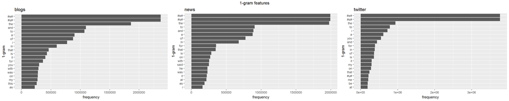

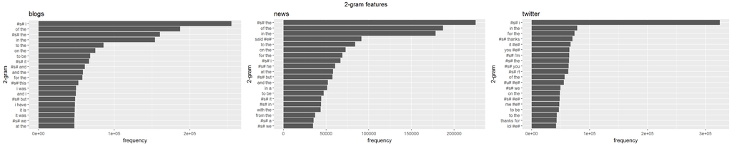

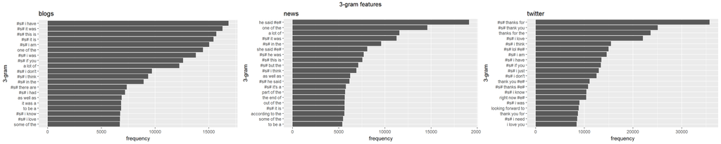

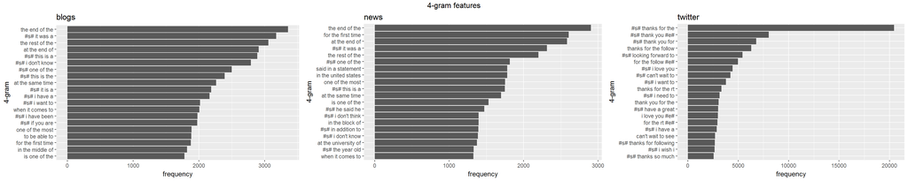

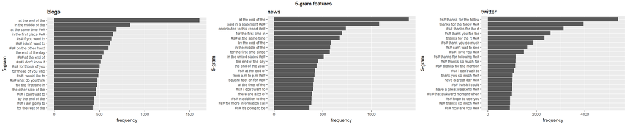

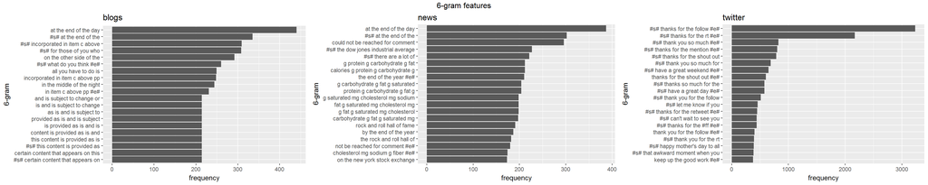

```r
# generating a list of top 20 features
top=20
topfeatures.file <- file.path(dataDir, "topfeatures.bydoc.rda")
if(!file.exists(topfeatures.file)) {
    topfeatures.bydoc <-
        lapply(1:6, function(ngram) { #19min
            sapply(docs, function(doc) {
                dfm <- paste0(doc, ".dfm.", ngram, "gram")
                load(file.path(dataDir, paste0(dfm, ".rda")))
                tf <- topfeatures(get(dfm), top)
                rm(list=dfm)
                tf
            }, simplify = FALSE)
        })
    save(topfeatures.bydoc, file=topfeatures.file, compress=FALSE)
} else load(topfeatures.file)
# plotting the top 20 features
for(ngram in seq_along(topfeatures.bydoc)) {
    grobs <- lapply(seq_along(topfeatures.bydoc[[ngram]]), function(doc) {
        frequency <- topfeatures.bydoc[[ngram]][[doc]]
        df <- data.frame(frequency = frequency,
                         feature = factor(names(frequency), levels = names(sort(frequency))))
        ggplot(df, aes(feature, frequency)) + geom_col() + coord_flip() +
                labs(title=docs[doc], x=paste0(ngram, "-gram"))
    })
    grid.arrange(grobs = grobs, ncol=length(docs),
                 top=paste0(ngram,"-gram"," features"))
}
```

## 4.5 Findings

There are hundred millions tokens from the given texts.

There are more tokens in the blogs, followed by news and twitter.

The top 1-grams show the vocabularies are somewhat similar although one can see high frequencies of pronoun “you” in twitter messages and the pronoun “I” in both blogs and twitter which agree with the fact that blogs are meant to be a kind of biography written in first person, while twitter is meant to be both a kind of biography but also frequently replying to someone else’s twitter, and finally, news are more likely to be written in third person.

Comparing the top 2-grams with the top 3-grams and so on, one can see how the English language model start to build up and how some kind of jargons appear, e.g.:

- Blogs and News: “at the end of”
- Twitter: “thanks for the shout out”

# 5 Prediction algorithm proposal

The proposal is to develop a prediction algorithm that does the following:

- takes the last *n* words from a given text, limited to a maximum of 4 words, and look for the next word in a *n+1* n-gram table.
- To improve the chances to find a next word, if the *n* words are not found in the *n+1* n-gram table, the algorithm shall successively fall back to look for the last *n-1* words in lower order *n*-gram tables.